# Statistics : Examples from Epidemiology

## More on confounding : Do doctors commit more sexual harressment?

[figure not shown]

*Figure: National crime statistics*

According to the national crime statistic, doctors were ranked the second most job which committed sexual harressment. One might think that being a doctor is correlated to committing sexual crimes. However, this is a typical example of confounding. One can describe the current problem in a form of *Directed Acyclic Graph* (DAGs) as follows.

[figure not shown]

*Figure: DAG of being a doctor and committing a crime (Generated by DAGitty v2.3)*

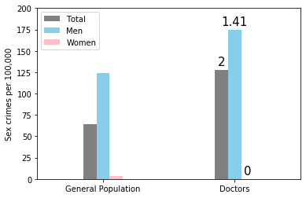

```python
# import required libraries
import numpy as np
import matplotlib.pyplot as plt
import statsmodels.api as sm
import pandas as pd
import colour as colour

# Parameter Data: 2017 기준 KOSIS 여성범죄자 통계, 보건통계연보, 검찰청 범죄통계
data_pop = pd.DataFrame([[51422507,25768055,25654452],[108000,79000,29000]],
                        index=['general', 'doctor'],
                         columns=['total', 'men', 'women'])
data_crime = pd.DataFrame([[32837,31905,829],[138,138,0]],
                        index=['general', 'doctor'],
                         columns=['total', 'men', 'women'])
data_cr = data_crime / data_pop * 100000


# Draw figures : Crime rate
x = np.arange(len(data_pop.index)) * 2
labels = ['General Population', 'Doctors']
width = 0.2
fig, ax = plt.subplots()
rects1 = ax.bar(x-width, data_cr['total'], width, label='Total', color='grey')
rects2 = ax.bar(x, data_cr['men'], width, label='Men', color='skyblue')
rects3 = ax.bar(x+width, data_cr['women'], width, label='Women', color='pink')

ax.set_ylabel('Sex crimes per 100,000')
ax.set_ylim([0,200])
ax.set_xticks(x)
ax.set_xticklabels(labels)
ax.set_xlim([-1,3])
ax.legend()

# label doctor/general ratio on top
for dx, ycor, num in zip([-width,0,width], data_cr.loc['doctor',:], data_cr.loc['doctor',:]/data_cr.loc['general',:]):
    ax.text(x=x[1]+dx, y=ycor+5, ha='center', s='%.3g' % num, fontsize=15)

plt.show()
```

The labels on top of the bars are the crime rate of doctors divided by the crime rate of the general population. After stratifying sex, the incidence of sex crimes droped from 2 to 1.41, which means that approximately 60% of increased sex crime incidences by doctors are explained by the sex ratio among doctors.

### From this we see that by increasing the number of female doctors, crime rate of doctors will decrease without any other intervention.

## Collider Bias

Just like confounding, collider is a common bias introduced to everyday life decisions. The name 'collider' comes from the shape of the following DAG.

[figure not shown]

*Figure: Exposure (E) and Outcome (O) collides at Z*

We see that the directions of the arrows are flipped compared to the DAG of confounders. Opposite to the case of confounding where adjustement of the confounder is required to obtain the right answer, collider variables should not be adjusted.

A research from 1929 is a classic example that ended up with a false protective effect of tuberculosis on cancer.

[figure not shown]

Both tuberculosis and cancer increases the risk of hospitalization. In other words, people with tuberculosis has a higher incidence of being hospitalized compared to people without them. Therefore, if we count only on people who are hospitalized, those with tuberculosis has a smaller chance of having cancer.

In this example, tuberculosis is the exposure and cancer is the outcome. Most importantly, being hospitalized is the collider. Thus, carrying out an analysis only on hospitalzed patients, which is in this case adjusting for the collider, resulted in a false association between cancer and tuberculosis.

For a better understanding, let's consider a toy example. Suppose that there are two baskets on the table where one contains contaminated apples and the other contains contaminated pears. People who were walking by the desk will take an apple or a pear or both with certain amount of probability, in which that will make them sick, but suppose that eating an apple and eating a pear are indpenedent.

```python
import scipy.stats as stats

# length n dataframe
n = 5000
df = pd.DataFrame(columns=['pear', 'apple', 'sick'], index=range(n))

# assign pear, apple and sick
df['pear'] = np.random.binomial(n=1,p=1/2,size=n)
df['apple'] = np.random.binomial(n=1,p=1/2,size=n)
df['sick'] = np.random.binomial(n=1,p=1/3 * df['pear'] + 1/3 * df['apple'] + 1/6,size=n)

# contingency table apple x pear
ct = pd.crosstab(df['pear'], df['apple'])
print(stats.fisher_exact(ct))

# contingency table apple x pear with adjustment
df_sick = df[df['sick'] == 1]
ct_sick = pd.crosstab(df_sick['pear'], df_sick['apple'])
print(stats.fisher_exact(ct_sick))
```

```
(1.0542785254750193, 0.3507940715073325)
(0.5598214285714286, 3.5568119965645703e-10)
```

## A negative association between eating an apple and a pear was observed!

## Instrumental variable : occupational participation of women and number of children

We have previously learned about the cases when the error term $\epsilon$ and the exposure $X$ is corrleated. $$ Y= X \beta + \epsilon$$

We have also learned that the OLS estimates under such conditions are biased. As an alternative there is a method called the *instrumental variable estimation* which employs a additional variable $Z$ called the *instrumental variable* that is correlated to $X$ but not $\epsilon$ to overcome such situations.

[figure not shown]

In South Korea, parents prefer boys over girls which results in an increased number of total children per household. Therefore, the sex of the first child of each household is correlated to the total number of childer per household but not correlated to any $\epsilon$ since sex of a child is determined by pure chance at fertilization. Therefore, using $Z$ as an IV, one can estimate the causal effect of number of children per household on labor market participation of women.